# eda-trip

```python
# This Python 3 environment comes with many helpful analytics libraries installed
# It is defined by the kaggle/python docker image: https://github.com/kaggle/docker-python
# For example, here's several helpful packages to load in

import numpy as np # linear algebra
import pandas as pd # data processing, CSV file I/O (e.g. pd.read_csv)

# Input data files are available in the "../input/" directory.
# For example, running this (by clicking run or pressing Shift+Enter) will list the files in the input directory

import os
print(os.listdir("../input"))

# Any results you write to the current directory are saved as output.
```

```
['input_data']
```

```python
from tqdm import tqdm
import os, gc
import seaborn as sns
import matplotlib.pyplot as plt
```

```python
### get all paraquet files
tripF = [i for i in os.listdir('../input/input_data/trip/') if 'parquet' in i]
print("Total {} trip files".format(len(tripF)))
```

```
Total 43 trip files
```

```python
### lets build one dataframe each for trip, drive, and weather
Path = '../input/input_data/'

def consolidateFiles(sourceType:str,iterfiles:list):
    print(" ------  Consolidating for {} ------- ".format(sourceType))
    outDF = pd.DataFrame()
    for f_ in tqdm(iterfiles):
        outDF = pd.concat([outDF,pd.read_parquet(os.path.join(Path,'{}/{}'.format(sourceType,f_)))],0)
    return outDF
tripDF = consolidateFiles('trip',tripF)
tripDF.head()
```

```
 ------  Consolidating for trip -------
```

|  | vehicle_id | trip_id | datetime | lat | long | velocity |
| --- | --- | --- | --- | --- | --- | --- |
| 0 | 1000518 | 8e2f7799f577423c9343d1eddbbaa2b6 | 2017-01-06 19:00:00 | 30.312500 | -93.8125 | 0.00 |
| 1 | 1000518 | 8e2f7799f577423c9343d1eddbbaa2b6 | 2017-01-06 19:00:01 | 30.312778 | -93.8125 | 70.06 |
| 2 | 1000518 | 8e2f7799f577423c9343d1eddbbaa2b6 | 2017-01-06 19:00:02 | 30.313056 | -93.8125 | 74.38 |
| 3 | 1000518 | 8e2f7799f577423c9343d1eddbbaa2b6 | 2017-01-06 19:00:03 | 30.313333 | -93.8125 | 71.28 |
| 4 | 1000518 | 8e2f7799f577423c9343d1eddbbaa2b6 | 2017-01-06 19:00:04 | 30.313611 | -93.8125 | 77.70 |

### Univariate Analysis

Vehicles

```python
print("Total unique vehicle IDs {}".format(tripDF['vehicle_id'].nunique()))
```

```
Total unique vehicle IDs 20
```

Trips

```python
print("Total trip IDs {}".format(tripDF['trip_id'].nunique()))
```

```
Total trip IDs 1708
```

Days and hours

```python
print("Total unique days {}".format(pd.to_datetime(tripDF['datetime']).dt.day.nunique()))
print("Total unique hours {}".format(pd.to_datetime(tripDF['datetime']).dt.hour.nunique()))
```

```
Total unique days 30
Total unique hours 24
```

Latitude, Longiude

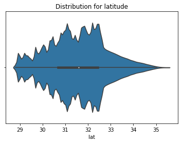

```python
sns.violinplot(tripDF['lat'])
plt.title("Distribution for latitude")
```

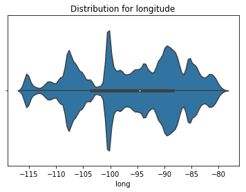

```python
sns.violinplot(tripDF['long'])
plt.title("Distribution for longitude")
```

- Latitudes and longitudes are confined within respective ranges (29 to 35),(-115 to -80)
- Majority latitudes are b/w 31-33

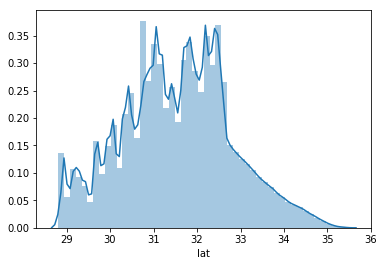

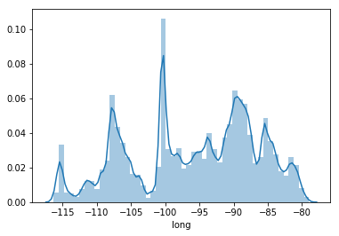

```python
sns.distplot(tripDF['lat'])
plt.show()
sns.distplot(tripDF['long'])
plt.show()
```

Velocity

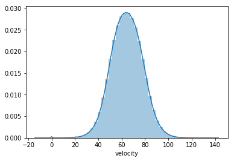

```python
sns.distplot(tripDF['velocity'])
```

```python
print("Mean: {}, Variance: {}".format(tripDF['velocity'].mean(),tripDF['velocity'].var()))
```

```
Mean: 64.40624283539142, Variance: 174.97073727101088
```

- Velocity is normally distriuted with mean ~ 64 and variance of ~ 175

### Multivariate analysis

- Note that all datetime analysis is as per local time/UTC

```python
###
tripDF['day'] = pd.to_datetime(tripDF['datetime']).dt.day
tripDF['hour'] = pd.to_datetime(tripDF['datetime']).dt.hour
```

### Vehicle

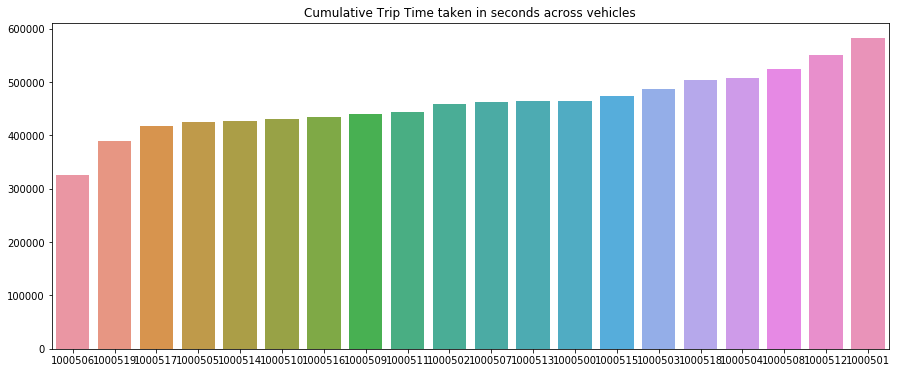

```python
_ = tripDF['vehicle_id'].value_counts().sort_values()
plt.figure(figsize=(15,6))
x = _.index
y = _.values
sns.barplot(_.index,_.values,order=_.index)
plt.title("Cumulative Trip Time taken in seconds across vehicles")
```

- Minimum each vehicle travelled for atleast 300000 seconds, while the maximum time spent on road is around 600000 seconds

```python
tripDF.head()
```

|  | vehicle_id | trip_id | datetime | lat | long | velocity | day | hour |
| --- | --- | --- | --- | --- | --- | --- | --- | --- |
| 0 | 1000518 | 8e2f7799f577423c9343d1eddbbaa2b6 | 2017-01-06 19:00:00 | 30.312500 | -93.8125 | 0.00 | 6 | 19 |
| 1 | 1000518 | 8e2f7799f577423c9343d1eddbbaa2b6 | 2017-01-06 19:00:01 | 30.312778 | -93.8125 | 70.06 | 6 | 19 |
| 2 | 1000518 | 8e2f7799f577423c9343d1eddbbaa2b6 | 2017-01-06 19:00:02 | 30.313056 | -93.8125 | 74.38 | 6 | 19 |
| 3 | 1000518 | 8e2f7799f577423c9343d1eddbbaa2b6 | 2017-01-06 19:00:03 | 30.313333 | -93.8125 | 71.28 | 6 | 19 |
| 4 | 1000518 | 8e2f7799f577423c9343d1eddbbaa2b6 | 2017-01-06 19:00:04 | 30.313611 | -93.8125 | 77.70 | 6 | 19 |

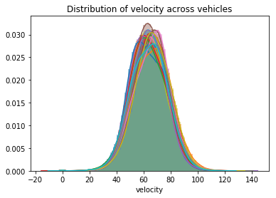

```python
for v_ in tripDF['vehicle_id'].unique():
    _ = tripDF[tripDF['vehicle_id']==v_]
    sns.distplot(_['velocity'])
    plt.title("Distribution of velocity across vehicles")
```

- Not much difference for velocity distribution across vehicles with mean ~65

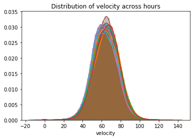

```python
for v_ in tripDF['hour'].unique():
    _ = tripDF[tripDF['hour']==v_]
    sns.distplot(_['velocity'])
    plt.title("Distribution of velocity across hours")
```

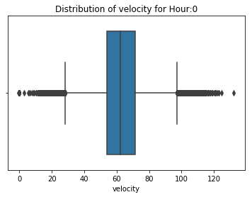

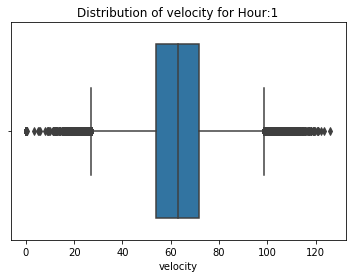

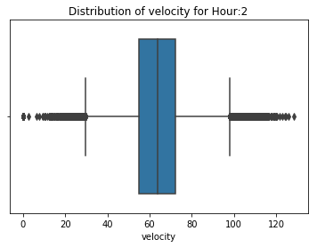

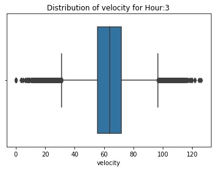

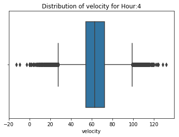

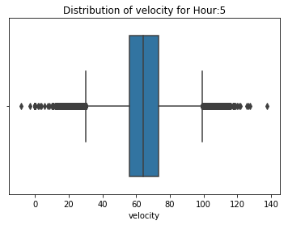

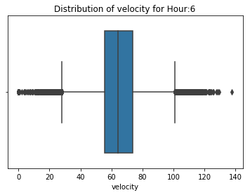

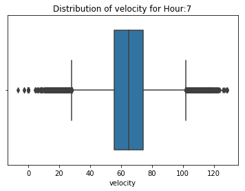

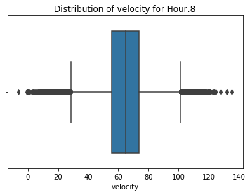

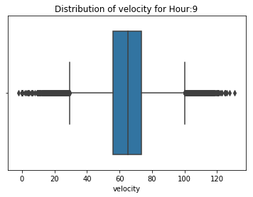

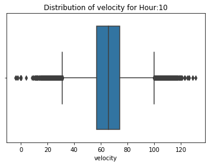

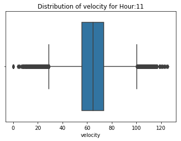

[12 more figures not shown]

```python
for v_ in np.sort(tripDF['hour'].unique()):
    _ = tripDF[tripDF['hour']==v_]
    sns.boxplot(_['velocity'])
    plt.title("Distribution of velocity for Hour:{}".format(v_))
    plt.show()
```

- Across hours there is not much observable difference in velocity distributions

### Trips

```python
top10trips = tripDF['trip_id'].value_counts().sort_values()[-10:]
bottom10trips = tripDF['trip_id'].value_counts().sort_values()[:10]
```

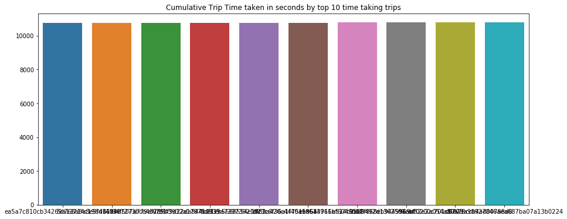

```python
plt.figure(figsize=(15,6))
x = top10trips.index
y = top10trips.values
sns.barplot(x,y,order=x)
plt.title("Cumulative Trip Time taken in seconds by top 10 time taking trips")
```

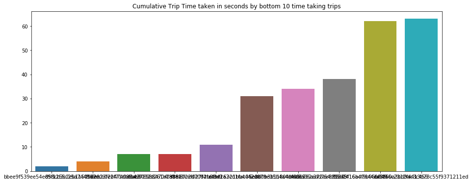

```python
plt.figure(figsize=(15,6))
x = bottom10trips.index
y = bottom10trips.values
sns.barplot(x,y,order=x)
plt.title("Cumulative Trip Time taken in seconds by bottom 10 time taking trips")
```

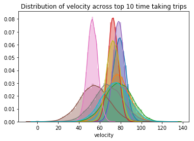

```python
for v_ in top10trips.index:
    _ = tripDF[tripDF['trip_id']==v_]
    sns.distplot(_['velocity'])
    plt.title("Distribution of velocity across top 10 time taking trips")
```

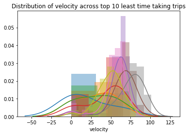

```python
for v_ in bottom10trips.index[1:]:
    _ = tripDF[tripDF['trip_id']==v_]
    sns.distplot(_['velocity'])
    plt.title("Distribution of velocity across top 10 least time taking trips")
```

- Longer trips have narrow velocity distribution while shorter trips generally seem to have wider distribution

### Hour

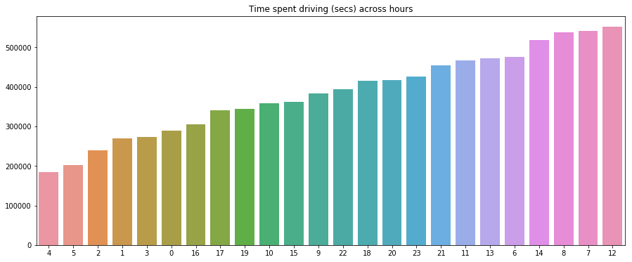

```python
topHours = tripDF['hour'].value_counts().sort_values()
plt.figure(figsize=(15,6))
x = topHours.index
y = topHours.values
sns.barplot(x,y,order=x)
plt.title("Time spent driving (secs) across hours")
```

```python
tripDF.head()
```

|  | vehicle_id | trip_id | datetime | lat | long | velocity | day | hour |
| --- | --- | --- | --- | --- | --- | --- | --- | --- |
| 0 | 1000518 | 8e2f7799f577423c9343d1eddbbaa2b6 | 2017-01-06 19:00:00 | 30.312500 | -93.8125 | 0.00 | 6 | 19 |
| 1 | 1000518 | 8e2f7799f577423c9343d1eddbbaa2b6 | 2017-01-06 19:00:01 | 30.312778 | -93.8125 | 70.06 | 6 | 19 |
| 2 | 1000518 | 8e2f7799f577423c9343d1eddbbaa2b6 | 2017-01-06 19:00:02 | 30.313056 | -93.8125 | 74.38 | 6 | 19 |
| 3 | 1000518 | 8e2f7799f577423c9343d1eddbbaa2b6 | 2017-01-06 19:00:03 | 30.313333 | -93.8125 | 71.28 | 6 | 19 |
| 4 | 1000518 | 8e2f7799f577423c9343d1eddbbaa2b6 | 2017-01-06 19:00:04 | 30.313611 | -93.8125 | 77.70 | 6 | 19 |

Fin